# Understanding Regression Coefficients

Matthew Aiello-Lammens

## Section Goals

- Introduce the equations for estimating simple linear regression coefficients
- Identify that regression coefficients are stastics that are t-distributed

## Simple linear model

Recall that the equation to define any given response value $y_i$ based on knowing predictor value $x_i$ is:

$$y_i = \beta_0 + \beta_1*x_i + \epsilon_i$$

Considering all values

$$Y = \beta_0 + \beta_1*X + \epsilon$$

where

$$\epsilon \sim N(0,\sigma^2)$$

Now, when *estimating* our model parameters we write this as:

$$Y = b_0 + b_1*X + e$$

and we are trying to estimate $\beta_0$, $\beta_1$, and $\sigma$.

Below we note the equations used to estimate the coefficient values. A detailed description of the mathematics can be found in Chapter 6 of Vu and Harrington (and Chapter 5 of Quinn and Keough).

### $\beta_0$ estimate

$$b_0 = \bar{y} - b_1 *\bar{x}$$

### $\beta_1$ estimate

$$b_1 = \frac{\sum_{i=1}^n{[(x_i - \bar{x})(y_i -
\bar{y})]}}{\sum_{i=1}^n{(x_i - \bar{x})^2}}$$

Note that this is the co-variance between X and Y, divided by the variance of X.

### $\epsilon$ estimate

$$e_i = y_i - \hat{y}_i$$

and thus $s$, the estimate for $\sigma$ is the standard deviation of the residuals.

## Model parameters / coefficients are statistics

Model parameters are statistics, and we can calculate standard errors for these statistics.

In what follows, we are most interested in looking at the standard errors for the $b_0$ and $b_1$ parameters, which are also called our **linear regression coefficients**.

### $\beta_0$ standard error

$$s_{b_{0}} = \sqrt{ MS_{Residual} [\frac{1}{n} +
\frac{\bar{x}^2}{\sum^n_{i=1}(x_i-\bar{x})^2}] }$$

### $\beta_1$ standard error

$$s_{b_{1}} = \sqrt{ \frac{MS_{Residual}}{\sum^n_{i=1}(x_i-\bar{x})^2} }$$

What is MS_Residual?

It’s the Mean Sums of Squares Residuals (see figure in [Section 12 notes](https://mlammens.github.io/ENS-623-Research-Stats/lectures/12-Linear-Regression.html#model-evalutation)).

Note that the degrees of freedom used to calculate MS_Residuals is the number of observations minus the number of coefficients being estimated. So hear, $n - 2$, because we are estimating $\beta_0$ and $\beta_1$.

Once we have the **standard error of regression coefficient** values, we can use them and the *t*-distribution to determine confidence intervals.

For example, the confidence interval for $b_1$ is:

$$b_1 \pm t_{0.05, n-2}s_{b_{1}}$$

Similarly, we can also calculate a standard error for our predicted $y$ values, $\hat{y}_i$:

### $\hat{y}_i$ standard error

$$s_{\hat{y}} = \sqrt{ MS_{Residual} [1 + \frac{1}{n} + \frac{x_p -
\bar{x}^2}{\sum^n_{i=1}(x_i-\bar{x})^2}] }$$

where $x_p$ is the value from $x$ we are “predicting” a $y$ value for.

We can use these standard errors to calculate confidence intervals, and ultimately calculate and display a confidence interval for the regression line itself.

To demonstrate, let’s return to our Flour Beetle example.

```r
flr_beetle <- read.csv(file = "https://mlammens.github.io/ENS-623-Research-Stats/data/Logan_Examples/Chapter8/Data/nelson.csv")
```

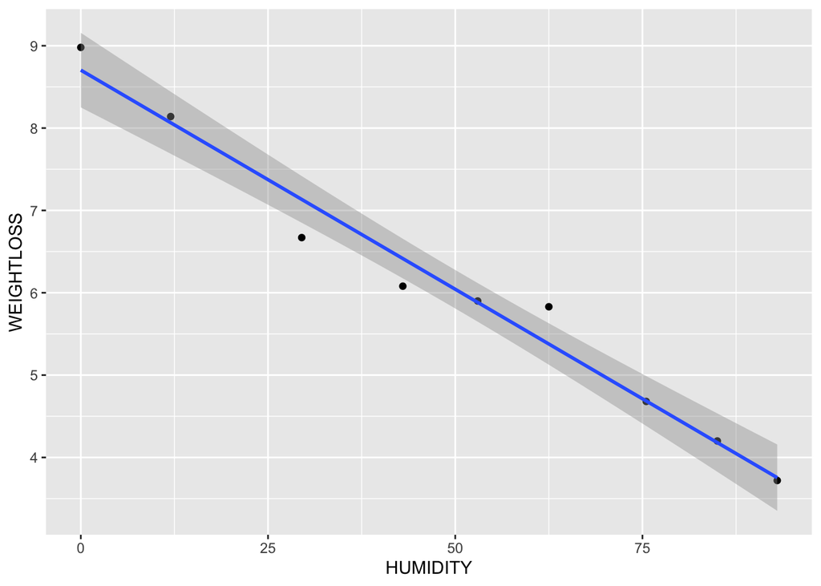

```r
library(ggplot2)

ggplot(data = flr_beetle, aes(x = HUMIDITY, y = WEIGHTLOSS)) +
  geom_point() +
  geom_smooth(method = "lm")
```

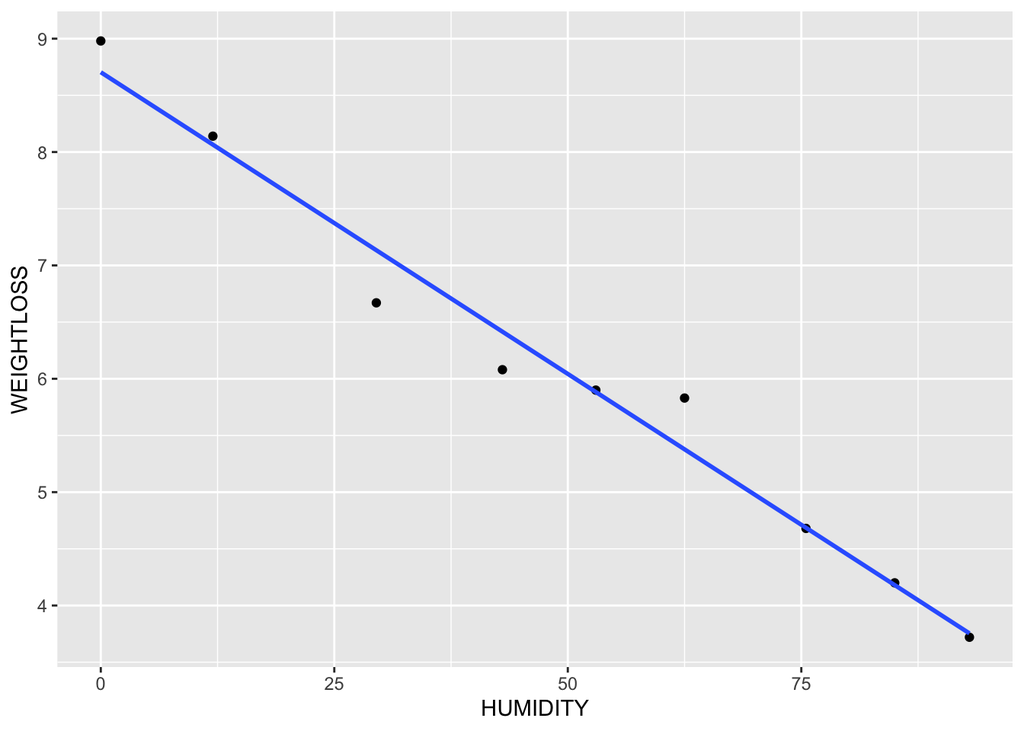

```r
ggplot(data = flr_beetle, aes(x = HUMIDITY, y = WEIGHTLOSS)) +
  geom_point() +
  geom_smooth(method = "lm", se = FALSE)
```

## Testing whether coefficients are *significant*

We can also use our standard error values to examine whether the coefficient estimates resulting from a linear regression are **significantly** different from 0 using a **Wald Test** (similar to the $t$ test).

```r
flr_beetle_lm <- lm(data = flr_beetle, WEIGHTLOSS~HUMIDITY)

summary(flr_beetle_lm)
```

```
##
## Call:
## lm(formula = WEIGHTLOSS ~ HUMIDITY, data = flr_beetle)
##
## Residuals:
##      Min       1Q   Median       3Q      Max
## -0.46397 -0.03437  0.01675  0.07464  0.45236
##
## Coefficients:
##              Estimate Std. Error t value Pr(>|t|)
## (Intercept)  8.704027   0.191565   45.44 6.54e-10 ***
## HUMIDITY    -0.053222   0.003256  -16.35 7.82e-07 ***
## ---
## Signif. codes:  0 '***' 0.001 '**' 0.01 '*' 0.05 '.' 0.1 ' ' 1
##
## Residual standard error: 0.2967 on 7 degrees of freedom
## Multiple R-squared:  0.9745, Adjusted R-squared:  0.9708
## F-statistic: 267.2 on 1 and 7 DF,  p-value: 7.816e-07
```

```r
(8.704027 - 0)/0.191565
```

```
## [1] 45.43642
```

```r
pt(q = 45.44, df = (9-2), lower.tail = FALSE) * 2
```

```
## [1] 6.53332e-10
```

Reject our null that intercept is 0, and support alternative that it’s not 0.